# Risk Factor Analysis

## Outcome Variable

**Outcome Variable:** ever_sstunted

## Predictor Variables

**Intervention Variable:** parity

**Adjustment Set:**

- arm
- W_mage
- meducyrs
- feducyrs
- hhwealth_quart
- W_mhtcm
- W_mwtkg
- W_mbmi
- vagbrth
- W_nrooms
- impsan
- delta_W_mage
- delta_meducyrs
- delta_feducyrs
- delta_hhwealth_quart
- delta_W_mhtcm
- delta_W_mwtkg
- delta_W_mbmi
- delta_vagbrth
- delta_W_nrooms
- delta_impsan

## Stratifying Variables

The analysis was stratified on these variable(s):

- agecat
- studyid
- country

## Data Summary

| agecat | studyid | country | parity | ever_sstunted | n_cell | n |
| --- | --- | --- | --- | --- | --- | --- |
| 0-24 months | ki1000304b-SAS-CompFeed | INDIA | 1 | 0 | 310 | 1533 |
| 0-24 months | ki1000304b-SAS-CompFeed | INDIA | 1 | 1 | 142 | 1533 |
| 0-24 months | ki1000304b-SAS-CompFeed | INDIA | 2 | 0 | 261 | 1533 |
| 0-24 months | ki1000304b-SAS-CompFeed | INDIA | 2 | 1 | 99 | 1533 |
| 0-24 months | ki1000304b-SAS-CompFeed | INDIA | 3+ | 0 | 455 | 1533 |
| 0-24 months | ki1000304b-SAS-CompFeed | INDIA | 3+ | 1 | 266 | 1533 |
| 0-24 months | ki1000304b-SAS-FoodSuppl | INDIA | 1 | 0 | 17 | 418 |
| 0-24 months | ki1000304b-SAS-FoodSuppl | INDIA | 1 | 1 | 4 | 418 |
| 0-24 months | ki1000304b-SAS-FoodSuppl | INDIA | 2 | 0 | 46 | 418 |
| 0-24 months | ki1000304b-SAS-FoodSuppl | INDIA | 2 | 1 | 31 | 418 |
| 0-24 months | ki1000304b-SAS-FoodSuppl | INDIA | 3+ | 0 | 154 | 418 |
| 0-24 months | ki1000304b-SAS-FoodSuppl | INDIA | 3+ | 1 | 166 | 418 |
| 0-24 months | ki1017093b-PROVIDE | BANGLADESH | 1 | 0 | 227 | 700 |
| 0-24 months | ki1017093b-PROVIDE | BANGLADESH | 1 | 1 | 44 | 700 |
| 0-24 months | ki1017093b-PROVIDE | BANGLADESH | 2 | 0 | 214 | 700 |
| 0-24 months | ki1017093b-PROVIDE | BANGLADESH | 2 | 1 | 30 | 700 |
| 0-24 months | ki1017093b-PROVIDE | BANGLADESH | 3+ | 0 | 164 | 700 |
| 0-24 months | ki1017093b-PROVIDE | BANGLADESH | 3+ | 1 | 21 | 700 |
| 0-24 months | ki1066203-TanzaniaChild2 | TANZANIA, UNITED REPUBLIC OF | 1 | 0 | 750 | 2357 |
| 0-24 months | ki1066203-TanzaniaChild2 | TANZANIA, UNITED REPUBLIC OF | 1 | 1 | 71 | 2357 |
| 0-24 months | ki1066203-TanzaniaChild2 | TANZANIA, UNITED REPUBLIC OF | 2 | 0 | 688 | 2357 |
| 0-24 months | ki1066203-TanzaniaChild2 | TANZANIA, UNITED REPUBLIC OF | 2 | 1 | 83 | 2357 |
| 0-24 months | ki1066203-TanzaniaChild2 | TANZANIA, UNITED REPUBLIC OF | 3+ | 0 | 685 | 2357 |
| 0-24 months | ki1066203-TanzaniaChild2 | TANZANIA, UNITED REPUBLIC OF | 3+ | 1 | 80 | 2357 |
| 0-24 months | ki1101329-Keneba | GAMBIA | 1 | 0 | 182 | 1990 |
| 0-24 months | ki1101329-Keneba | GAMBIA | 1 | 1 | 59 | 1990 |
| 0-24 months | ki1101329-Keneba | GAMBIA | 2 | 0 | 173 | 1990 |
| 0-24 months | ki1101329-Keneba | GAMBIA | 2 | 1 | 41 | 1990 |
| 0-24 months | ki1101329-Keneba | GAMBIA | 3+ | 0 | 1158 | 1990 |
| 0-24 months | ki1101329-Keneba | GAMBIA | 3+ | 1 | 377 | 1990 |

[output cut: 102 more lines]

The following strata were considered:

- agecat: 0-24 months, studyid: ki1000304b-SAS-CompFeed, country: INDIA
- agecat: 0-24 months, studyid: ki1000304b-SAS-FoodSuppl, country: INDIA
- agecat: 0-24 months, studyid: ki1017093b-PROVIDE, country: BANGLADESH
- agecat: 0-24 months, studyid: ki1066203-TanzaniaChild2, country: TANZANIA, UNITED REPUBLIC OF
- agecat: 0-24 months, studyid: ki1101329-Keneba, country: GAMBIA
- agecat: 0-24 months, studyid: ki1113344-GMS-Nepal, country: NEPAL
- agecat: 0-24 months, studyid: ki1126311-ZVITAMBO, country: ZIMBABWE
- agecat: 0-24 months, studyid: ki1135781-COHORTS, country: GUATEMALA
- agecat: 0-24 months, studyid: ki1135781-COHORTS, country: INDIA
- agecat: 0-24 months, studyid: ki1135781-COHORTS, country: PHILIPPINES
- agecat: 0-24 months, studyid: kiGH5241-JiVitA-3, country: BANGLADESH
- agecat: 0-6 months, studyid: ki1000304b-SAS-CompFeed, country: INDIA
- agecat: 0-6 months, studyid: ki1000304b-SAS-FoodSuppl, country: INDIA
- agecat: 0-6 months, studyid: ki1017093b-PROVIDE, country: BANGLADESH
- agecat: 0-6 months, studyid: ki1066203-TanzaniaChild2, country: TANZANIA, UNITED REPUBLIC OF
- agecat: 0-6 months, studyid: ki1101329-Keneba, country: GAMBIA
- agecat: 0-6 months, studyid: ki1113344-GMS-Nepal, country: NEPAL
- agecat: 0-6 months, studyid: ki1126311-ZVITAMBO, country: ZIMBABWE
- agecat: 0-6 months, studyid: ki1135781-COHORTS, country: GUATEMALA
- agecat: 0-6 months, studyid: ki1135781-COHORTS, country: INDIA
- agecat: 0-6 months, studyid: ki1135781-COHORTS, country: PHILIPPINES
- agecat: 0-6 months, studyid: kiGH5241-JiVitA-3, country: BANGLADESH

### Dropped Strata

Some strata were dropped due to rare outcomes:

- agecat: 0-24 months, studyid: ki1000304b-SAS-FoodSuppl, country: INDIA
- agecat: 0-6 months, studyid: ki1000304b-SAS-FoodSuppl, country: INDIA

## Methods Detail

We’re interested in the causal parameters $E[Y_a]$ for all values of $a \in \mathcal{A}$. These parameters represent the mean outcome if, possibly contrary to fact, we intervened to set all units to have $A=a$. Under the randomization and positivity assumptions, these are identified by the statistical parameters $\psi_a=E_W[E_{Y|A,W}(Y|A=a,W)]$. In addition, we’re interested in the mean of $Y$, $E[Y]$ under no intervention (the observed mean). We will estimate these parameters by using SuperLearner to fit the relevant likelihood factors – $E_{Y|A,W}(Y|A=a,W)$ and $p(A=a|W)$, and then updating our likelihood fit using a joint TMLE.

For unadjusted analyses ($W=\{\}$), initial likelihoods were estimated using Lrnr_glm to estimate the simple $E(Y|A)$ and Lrnr_mean to estimate $p(A)$. For adjusted analyses, a small library containing Lrnr_glmnet, Lrnr_xgboost, and Lrnr_mean was used.

Having estimated these parameters, we will then use the delta method to estimate relative risks and attributable risks relative to a prespecified baseline level of $A$.

# Results Detail

## Results Plots

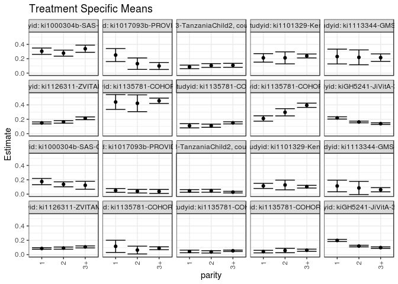

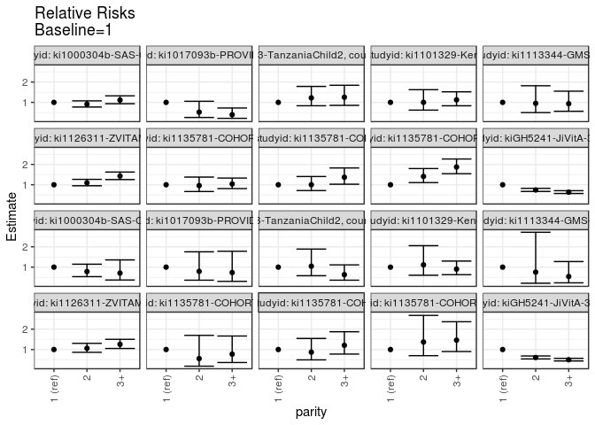

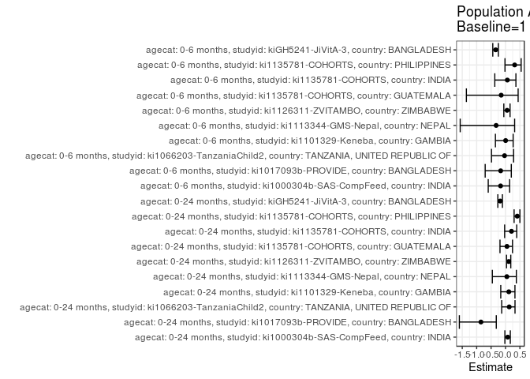

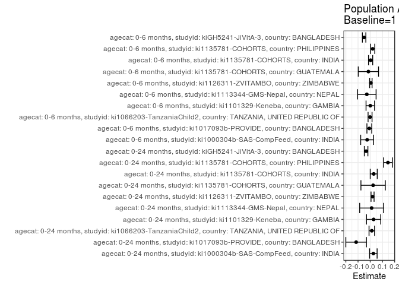

## Results Table

### Parameter: TSM

| agecat | studyid | country | intervention_level | baseline_level | estimate | ci_lower | ci_upper |
| --- | --- | --- | --- | --- | --- | --- | --- |
| 0-24 months | ki1000304b-SAS-CompFeed | INDIA | 1 | NA | 0.3050068 | 0.2609802 | 0.3490334 |
| 0-24 months | ki1000304b-SAS-CompFeed | INDIA | 2 | NA | 0.2779735 | 0.2358844 | 0.3200627 |
| 0-24 months | ki1000304b-SAS-CompFeed | INDIA | 3+ | NA | 0.3391180 | 0.2890019 | 0.3892341 |
| 0-24 months | ki1017093b-PROVIDE | BANGLADESH | 1 | NA | 0.2513314 | 0.1609596 | 0.3417033 |
| 0-24 months | ki1017093b-PROVIDE | BANGLADESH | 2 | NA | 0.1312363 | 0.0514022 | 0.2110704 |
| 0-24 months | ki1017093b-PROVIDE | BANGLADESH | 3+ | NA | 0.0992663 | 0.0507080 | 0.1478247 |
| 0-24 months | ki1066203-TanzaniaChild2 | TANZANIA, UNITED REPUBLIC OF | 1 | NA | 0.0864124 | 0.0614160 | 0.1114088 |
| 0-24 months | ki1066203-TanzaniaChild2 | TANZANIA, UNITED REPUBLIC OF | 2 | NA | 0.1055001 | 0.0794343 | 0.1315658 |
| 0-24 months | ki1066203-TanzaniaChild2 | TANZANIA, UNITED REPUBLIC OF | 3+ | NA | 0.1083394 | 0.0807952 | 0.1358835 |
| 0-24 months | ki1101329-Keneba | GAMBIA | 1 | NA | 0.2119376 | 0.1528158 | 0.2710594 |
| 0-24 months | ki1101329-Keneba | GAMBIA | 2 | NA | 0.2124342 | 0.1289657 | 0.2959026 |
| 0-24 months | ki1101329-Keneba | GAMBIA | 3+ | NA | 0.2385800 | 0.2115340 | 0.2656259 |
| 0-24 months | ki1113344-GMS-Nepal | NEPAL | 1 | NA | 0.2306480 | 0.1277033 | 0.3335927 |
| 0-24 months | ki1113344-GMS-Nepal | NEPAL | 2 | NA | 0.2195402 | 0.1161078 | 0.3229726 |
| 0-24 months | ki1113344-GMS-Nepal | NEPAL | 3+ | NA | 0.2155604 | 0.1635853 | 0.2675355 |
| 0-24 months | ki1126311-ZVITAMBO | ZIMBABWE | 1 | NA | 0.1491516 | 0.1355169 | 0.1627864 |
| 0-24 months | ki1126311-ZVITAMBO | ZIMBABWE | 2 | NA | 0.1635759 | 0.1456098 | 0.1815421 |
| 0-24 months | ki1126311-ZVITAMBO | ZIMBABWE | 3+ | NA | 0.2131958 | 0.1936616 | 0.2327300 |
| 0-24 months | ki1135781-COHORTS | GUATEMALA | 1 | NA | 0.4402854 | 0.3374583 | 0.5431125 |
| 0-24 months | ki1135781-COHORTS | GUATEMALA | 2 | NA | 0.4225608 | 0.3057119 | 0.5394097 |
| 0-24 months | ki1135781-COHORTS | GUATEMALA | 3+ | NA | 0.4575250 | 0.4203069 | 0.4947431 |
| 0-24 months | ki1135781-COHORTS | INDIA | 1 | NA | 0.1096942 | 0.0800000 | 0.1393884 |
| 0-24 months | ki1135781-COHORTS | INDIA | 2 | NA | 0.1099097 | 0.0876886 | 0.1321309 |
| 0-24 months | ki1135781-COHORTS | INDIA | 3+ | NA | 0.1501601 | 0.1353844 | 0.1649359 |
| 0-24 months | ki1135781-COHORTS | PHILIPPINES | 1 | NA | 0.2108346 | 0.1735429 | 0.2481262 |
| 0-24 months | ki1135781-COHORTS | PHILIPPINES | 2 | NA | 0.2971887 | 0.2470191 | 0.3473583 |
| 0-24 months | ki1135781-COHORTS | PHILIPPINES | 3+ | NA | 0.3944822 | 0.3646618 | 0.4243027 |
| 0-24 months | kiGH5241-JiVitA-3 | BANGLADESH | 1 | NA | 0.2183032 | 0.2024910 | 0.2341154 |
| 0-24 months | kiGH5241-JiVitA-3 | BANGLADESH | 2 | NA | 0.1625156 | 0.1507654 | 0.1742658 |
| 0-24 months | kiGH5241-JiVitA-3 | BANGLADESH | 3+ | NA | 0.1388010 | 0.1272862 | 0.1503159 |
| 0-6 months | ki1000304b-SAS-CompFeed | INDIA | 1 | NA | 0.1751257 | 0.1313795 | 0.2188718 |
| 0-6 months | ki1000304b-SAS-CompFeed | INDIA | 2 | NA | 0.1368733 | 0.1026366 | 0.1711100 |
| 0-6 months | ki1000304b-SAS-CompFeed | INDIA | 3+ | NA | 0.1237144 | 0.0685094 | 0.1789195 |
| 0-6 months | ki1017093b-PROVIDE | BANGLADESH | 1 | NA | 0.0516605 | 0.0252890 | 0.0780320 |
| 0-6 months | ki1017093b-PROVIDE | BANGLADESH | 2 | NA | 0.0409836 | 0.0160904 | 0.0658769 |
| 0-6 months | ki1017093b-PROVIDE | BANGLADESH | 3+ | NA | 0.0378378 | 0.0103234 | 0.0653522 |
| 0-6 months | ki1066203-TanzaniaChild2 | TANZANIA, UNITED REPUBLIC OF | 1 | NA | 0.0447050 | 0.0263280 | 0.0630820 |
| 0-6 months | ki1066203-TanzaniaChild2 | TANZANIA, UNITED REPUBLIC OF | 2 | NA | 0.0466982 | 0.0268070 | 0.0665894 |
| 0-6 months | ki1066203-TanzaniaChild2 | TANZANIA, UNITED REPUBLIC OF | 3+ | NA | 0.0282049 | 0.0172640 | 0.0391458 |
| 0-6 months | ki1101329-Keneba | GAMBIA | 1 | NA | 0.1149285 | 0.0789733 | 0.1508838 |
| 0-6 months | ki1101329-Keneba | GAMBIA | 2 | NA | 0.1277178 | 0.0600772 | 0.1953584 |
| 0-6 months | ki1101329-Keneba | GAMBIA | 3+ | NA | 0.1038556 | 0.0848991 | 0.1228121 |
| 0-6 months | ki1113344-GMS-Nepal | NEPAL | 1 | NA | 0.1138650 | 0.0330551 | 0.1946748 |
| 0-6 months | ki1113344-GMS-Nepal | NEPAL | 2 | NA | 0.0858984 | -0.0058220 | 0.1776187 |
| 0-6 months | ki1113344-GMS-Nepal | NEPAL | 3+ | NA | 0.0615120 | 0.0319376 | 0.0910864 |
| 0-6 months | ki1126311-ZVITAMBO | ZIMBABWE | 1 | NA | 0.0860592 | 0.0752541 | 0.0968643 |
| 0-6 months | ki1126311-ZVITAMBO | ZIMBABWE | 2 | NA | 0.0912834 | 0.0763647 | 0.1062022 |
| 0-6 months | ki1126311-ZVITAMBO | ZIMBABWE | 3+ | NA | 0.1081144 | 0.0943786 | 0.1218503 |
| 0-6 months | ki1135781-COHORTS | GUATEMALA | 1 | NA | 0.1159363 | 0.0310113 | 0.2008612 |
| 0-6 months | ki1135781-COHORTS | GUATEMALA | 2 | NA | 0.0642438 | 0.0099516 | 0.1185359 |
| 0-6 months | ki1135781-COHORTS | GUATEMALA | 3+ | NA | 0.0897268 | 0.0696453 | 0.1098082 |
| 0-6 months | ki1135781-COHORTS | INDIA | 1 | NA | 0.0449670 | 0.0268584 | 0.0630756 |
| 0-6 months | ki1135781-COHORTS | INDIA | 2 | NA | 0.0391326 | 0.0231916 | 0.0550737 |
| 0-6 months | ki1135781-COHORTS | INDIA | 3+ | NA | 0.0542283 | 0.0444844 | 0.0639723 |
| 0-6 months | ki1135781-COHORTS | PHILIPPINES | 1 | NA | 0.0425789 | 0.0246094 | 0.0605485 |
| 0-6 months | ki1135781-COHORTS | PHILIPPINES | 2 | NA | 0.0582153 | 0.0277023 | 0.0887283 |
| 0-6 months | ki1135781-COHORTS | PHILIPPINES | 3+ | NA | 0.0621415 | 0.0474301 | 0.0768530 |
| 0-6 months | kiGH5241-JiVitA-3 | BANGLADESH | 1 | NA | 0.1975831 | 0.1822354 | 0.2129308 |
| 0-6 months | kiGH5241-JiVitA-3 | BANGLADESH | 2 | NA | 0.1196384 | 0.1084101 | 0.1308667 |
| 0-6 months | kiGH5241-JiVitA-3 | BANGLADESH | 3+ | NA | 0.0983532 | 0.0881301 | 0.1085763 |

### Parameter: E(Y)

| agecat | studyid | country | intervention_level | baseline_level | estimate | ci_lower | ci_upper |
| --- | --- | --- | --- | --- | --- | --- | --- |
| 0-24 months | ki1000304b-SAS-CompFeed | INDIA | NA | NA | 0.3307241 | 0.3024794 | 0.3589688 |
| 0-24 months | ki1017093b-PROVIDE | BANGLADESH | NA | NA | 0.1357143 | 0.1103250 | 0.1611036 |
| 0-24 months | ki1066203-TanzaniaChild2 | TANZANIA, UNITED REPUBLIC OF | NA | NA | 0.0992787 | 0.0872038 | 0.1113537 |
| 0-24 months | ki1101329-Keneba | GAMBIA | NA | NA | 0.2396985 | 0.2209375 | 0.2584595 |
| 0-24 months | ki1113344-GMS-Nepal | NEPAL | NA | NA | 0.2421203 | 0.2103189 | 0.2739218 |
| 0-24 months | ki1126311-ZVITAMBO | ZIMBABWE | NA | NA | 0.1681234 | 0.1619444 | 0.1743023 |
| 0-24 months | ki1135781-COHORTS | GUATEMALA | NA | NA | 0.4639706 | 0.4374564 | 0.4904847 |
| 0-24 months | ki1135781-COHORTS | INDIA | NA | NA | 0.1384449 | 0.1284958 | 0.1483940 |
| 0-24 months | ki1135781-COHORTS | PHILIPPINES | NA | NA | 0.3561151 | 0.3391405 | 0.3730897 |
| 0-24 months | kiGH5241-JiVitA-3 | BANGLADESH | NA | NA | 0.1844493 | 0.1788538 | 0.1900447 |
| 0-6 months | ki1000304b-SAS-CompFeed | INDIA | NA | NA | 0.1496732 | 0.1307571 | 0.1685893 |
| 0-6 months | ki1017093b-PROVIDE | BANGLADESH | NA | NA | 0.0442857 | 0.0290345 | 0.0595370 |
| 0-6 months | ki1066203-TanzaniaChild2 | TANZANIA, UNITED REPUBLIC OF | NA | NA | 0.0432754 | 0.0350591 | 0.0514916 |
| 0-6 months | ki1101329-Keneba | GAMBIA | NA | NA | 0.1154884 | 0.1009322 | 0.1300446 |
| 0-6 months | ki1113344-GMS-Nepal | NEPAL | NA | NA | 0.0859599 | 0.0651504 | 0.1067694 |
| 0-6 months | ki1126311-ZVITAMBO | ZIMBABWE | NA | NA | 0.0912066 | 0.0864469 | 0.0959663 |
| 0-6 months | ki1135781-COHORTS | GUATEMALA | NA | NA | 0.1008249 | 0.0829501 | 0.1186997 |
| 0-6 months | ki1135781-COHORTS | INDIA | NA | NA | 0.0480662 | 0.0417969 | 0.0543355 |
| 0-6 months | ki1135781-COHORTS | PHILIPPINES | NA | NA | 0.0624591 | 0.0538810 | 0.0710373 |
| 0-6 months | kiGH5241-JiVitA-3 | BANGLADESH | NA | NA | 0.1473804 | 0.1423344 | 0.1524264 |

### Parameter: RR

| agecat | studyid | country | intervention_level | baseline_level | estimate | ci_lower | ci_upper |
| --- | --- | --- | --- | --- | --- | --- | --- |
| 0-24 months | ki1000304b-SAS-CompFeed | INDIA | 1 | 1 | 1.0000000 | 1.0000000 | 1.0000000 |
| 0-24 months | ki1000304b-SAS-CompFeed | INDIA | 2 | 1 | 0.9113683 | 0.7720976 | 1.0757607 |
| 0-24 months | ki1000304b-SAS-CompFeed | INDIA | 3+ | 1 | 1.1118375 | 0.9344291 | 1.3229282 |
| 0-24 months | ki1017093b-PROVIDE | BANGLADESH | 1 | 1 | 1.0000000 | 1.0000000 | 1.0000000 |
| 0-24 months | ki1017093b-PROVIDE | BANGLADESH | 2 | 1 | 0.5221641 | 0.2584253 | 1.0550644 |
| 0-24 months | ki1017093b-PROVIDE | BANGLADESH | 3+ | 1 | 0.3949618 | 0.2154275 | 0.7241176 |
| 0-24 months | ki1066203-TanzaniaChild2 | TANZANIA, UNITED REPUBLIC OF | 1 | 1 | 1.0000000 | 1.0000000 | 1.0000000 |
| 0-24 months | ki1066203-TanzaniaChild2 | TANZANIA, UNITED REPUBLIC OF | 2 | 1 | 1.2208905 | 0.8349862 | 1.7851475 |
| 0-24 months | ki1066203-TanzaniaChild2 | TANZANIA, UNITED REPUBLIC OF | 3+ | 1 | 1.2537479 | 0.8534088 | 1.8418883 |
| 0-24 months | ki1101329-Keneba | GAMBIA | 1 | 1 | 1.0000000 | 1.0000000 | 1.0000000 |
| 0-24 months | ki1101329-Keneba | GAMBIA | 2 | 1 | 1.0023431 | 0.6189147 | 1.6233120 |
| 0-24 months | ki1101329-Keneba | GAMBIA | 3+ | 1 | 1.1257088 | 0.8330141 | 1.5212471 |
| 0-24 months | ki1113344-GMS-Nepal | NEPAL | 1 | 1 | 1.0000000 | 1.0000000 | 1.0000000 |
| 0-24 months | ki1113344-GMS-Nepal | NEPAL | 2 | 1 | 0.9518411 | 0.4981980 | 1.8185568 |
| 0-24 months | ki1113344-GMS-Nepal | NEPAL | 3+ | 1 | 0.9345862 | 0.5628941 | 1.5517152 |
| 0-24 months | ki1126311-ZVITAMBO | ZIMBABWE | 1 | 1 | 1.0000000 | 1.0000000 | 1.0000000 |
| 0-24 months | ki1126311-ZVITAMBO | ZIMBABWE | 2 | 1 | 1.0967090 | 0.9508544 | 1.2649369 |
| 0-24 months | ki1126311-ZVITAMBO | ZIMBABWE | 3+ | 1 | 1.4293897 | 1.2561001 | 1.6265860 |
| 0-24 months | ki1135781-COHORTS | GUATEMALA | 1 | 1 | 1.0000000 | 1.0000000 | 1.0000000 |
| 0-24 months | ki1135781-COHORTS | GUATEMALA | 2 | 1 | 0.9597429 | 0.6686997 | 1.3774592 |
| 0-24 months | ki1135781-COHORTS | GUATEMALA | 3+ | 1 | 1.0391555 | 0.8123136 | 1.3293440 |
| 0-24 months | ki1135781-COHORTS | INDIA | 1 | 1 | 1.0000000 | 1.0000000 | 1.0000000 |
| 0-24 months | ki1135781-COHORTS | INDIA | 2 | 1 | 1.0019647 | 0.7149329 | 1.4042343 |
| 0-24 months | ki1135781-COHORTS | INDIA | 3+ | 1 | 1.3688973 | 1.0266395 | 1.8252560 |
| 0-24 months | ki1135781-COHORTS | PHILIPPINES | 1 | 1 | 1.0000000 | 1.0000000 | 1.0000000 |
| 0-24 months | ki1135781-COHORTS | PHILIPPINES | 2 | 1 | 1.4095824 | 1.1056095 | 1.7971288 |
| 0-24 months | ki1135781-COHORTS | PHILIPPINES | 3+ | 1 | 1.8710511 | 1.5445567 | 2.2665611 |
| 0-24 months | kiGH5241-JiVitA-3 | BANGLADESH | 1 | 1 | 1.0000000 | 1.0000000 | 1.0000000 |
| 0-24 months | kiGH5241-JiVitA-3 | BANGLADESH | 2 | 1 | 0.7444493 | 0.6723480 | 0.8242825 |
| 0-24 months | kiGH5241-JiVitA-3 | BANGLADESH | 3+ | 1 | 0.6358178 | 0.5708959 | 0.7081226 |
| 0-6 months | ki1000304b-SAS-CompFeed | INDIA | 1 | 1 | 1.0000000 | 1.0000000 | 1.0000000 |
| 0-6 months | ki1000304b-SAS-CompFeed | INDIA | 2 | 1 | 0.7815719 | 0.5338906 | 1.1441568 |
| 0-6 months | ki1000304b-SAS-CompFeed | INDIA | 3+ | 1 | 0.7064324 | 0.3680642 | 1.3558686 |
| 0-6 months | ki1017093b-PROVIDE | BANGLADESH | 1 | 1 | 1.0000000 | 1.0000000 | 1.0000000 |
| 0-6 months | ki1017093b-PROVIDE | BANGLADESH | 2 | 1 | 0.7933255 | 0.3588172 | 1.7540002 |
| 0-6 months | ki1017093b-PROVIDE | BANGLADESH | 3+ | 1 | 0.7324324 | 0.3012417 | 1.7808198 |
| 0-6 months | ki1066203-TanzaniaChild2 | TANZANIA, UNITED REPUBLIC OF | 1 | 1 | 1.0000000 | 1.0000000 | 1.0000000 |
| 0-6 months | ki1066203-TanzaniaChild2 | TANZANIA, UNITED REPUBLIC OF | 2 | 1 | 1.0445867 | 0.5780240 | 1.8877442 |
| 0-6 months | ki1066203-TanzaniaChild2 | TANZANIA, UNITED REPUBLIC OF | 3+ | 1 | 0.6309126 | 0.3584703 | 1.1104148 |
| 0-6 months | ki1101329-Keneba | GAMBIA | 1 | 1 | 1.0000000 | 1.0000000 | 1.0000000 |
| 0-6 months | ki1101329-Keneba | GAMBIA | 2 | 1 | 1.1112800 | 0.6009460 | 2.0549985 |
| 0-6 months | ki1101329-Keneba | GAMBIA | 3+ | 1 | 0.9036536 | 0.6293150 | 1.2975852 |
| 0-6 months | ki1113344-GMS-Nepal | NEPAL | 1 | 1 | 1.0000000 | 1.0000000 | 1.0000000 |
| 0-6 months | ki1113344-GMS-Nepal | NEPAL | 2 | 1 | 0.7543881 | 0.2095344 | 2.7160292 |
| 0-6 months | ki1113344-GMS-Nepal | NEPAL | 3+ | 1 | 0.5402189 | 0.2289780 | 1.2745175 |
| 0-6 months | ki1126311-ZVITAMBO | ZIMBABWE | 1 | 1 | 1.0000000 | 1.0000000 | 1.0000000 |
| 0-6 months | ki1126311-ZVITAMBO | ZIMBABWE | 2 | 1 | 1.0607049 | 0.8632651 | 1.3033016 |
| 0-6 months | ki1126311-ZVITAMBO | ZIMBABWE | 3+ | 1 | 1.2562796 | 1.0509327 | 1.5017502 |
| 0-6 months | ki1135781-COHORTS | GUATEMALA | 1 | 1 | 1.0000000 | 1.0000000 | 1.0000000 |
| 0-6 months | ki1135781-COHORTS | GUATEMALA | 2 | 1 | 0.5541300 | 0.1811158 | 1.6953800 |
| 0-6 months | ki1135781-COHORTS | GUATEMALA | 3+ | 1 | 0.7739319 | 0.3597906 | 1.6647754 |
| 0-6 months | ki1135781-COHORTS | INDIA | 1 | 1 | 1.0000000 | 1.0000000 | 1.0000000 |
| 0-6 months | ki1135781-COHORTS | INDIA | 2 | 1 | 0.8702521 | 0.4907821 | 1.5431262 |
| 0-6 months | ki1135781-COHORTS | INDIA | 3+ | 1 | 1.2059580 | 0.7759494 | 1.8742647 |
| 0-6 months | ki1135781-COHORTS | PHILIPPINES | 1 | 1 | 1.0000000 | 1.0000000 | 1.0000000 |
| 0-6 months | ki1135781-COHORTS | PHILIPPINES | 2 | 1 | 1.3672319 | 0.6981326 | 2.6776047 |
| 0-6 months | ki1135781-COHORTS | PHILIPPINES | 3+ | 1 | 1.4594431 | 0.9003598 | 2.3656922 |
| 0-6 months | kiGH5241-JiVitA-3 | BANGLADESH | 1 | 1 | 1.0000000 | 1.0000000 | 1.0000000 |
| 0-6 months | kiGH5241-JiVitA-3 | BANGLADESH | 2 | 1 | 0.6055093 | 0.5367747 | 0.6830455 |
| 0-6 months | kiGH5241-JiVitA-3 | BANGLADESH | 3+ | 1 | 0.4977812 | 0.4378730 | 0.5658858 |

### Parameter: PAR

| agecat | studyid | country | intervention_level | baseline_level | estimate | ci_lower | ci_upper |
| --- | --- | --- | --- | --- | --- | --- | --- |
| 0-24 months | ki1000304b-SAS-CompFeed | INDIA | 1 | NA | 0.0257173 | -0.0050075 | 0.0564420 |
| 0-24 months | ki1017093b-PROVIDE | BANGLADESH | 1 | NA | -0.1156172 | -0.2000730 | -0.0311613 |
| 0-24 months | ki1066203-TanzaniaChild2 | TANZANIA, UNITED REPUBLIC OF | 1 | NA | 0.0128663 | -0.0098506 | 0.0355832 |
| 0-24 months | ki1101329-Keneba | GAMBIA | 1 | NA | 0.0277609 | -0.0307061 | 0.0862279 |
| 0-24 months | ki1113344-GMS-Nepal | NEPAL | 1 | NA | 0.0114724 | -0.0864010 | 0.1093457 |
| 0-24 months | ki1126311-ZVITAMBO | ZIMBABWE | 1 | NA | 0.0189717 | 0.0065018 | 0.0314417 |
| 0-24 months | ki1135781-COHORTS | GUATEMALA | 1 | NA | 0.0236852 | -0.0762636 | 0.1236339 |
| 0-24 months | ki1135781-COHORTS | INDIA | 1 | NA | 0.0287507 | -0.0000386 | 0.0575400 |
| 0-24 months | ki1135781-COHORTS | PHILIPPINES | 1 | NA | 0.1452805 | 0.1093154 | 0.1812456 |
| 0-24 months | kiGH5241-JiVitA-3 | BANGLADESH | 1 | NA | -0.0338539 | -0.0485008 | -0.0192070 |
| 0-6 months | ki1000304b-SAS-CompFeed | INDIA | 1 | NA | -0.0254525 | -0.0781065 | 0.0272016 |
| 0-6 months | ki1017093b-PROVIDE | BANGLADESH | 1 | NA | -0.0073748 | -0.0271125 | 0.0123629 |
| 0-6 months | ki1066203-TanzaniaChild2 | TANZANIA, UNITED REPUBLIC OF | 1 | NA | -0.0014296 | -0.0176788 | 0.0148195 |
| 0-6 months | ki1101329-Keneba | GAMBIA | 1 | NA | 0.0005599 | -0.0344127 | 0.0355324 |
| 0-6 months | ki1113344-GMS-Nepal | NEPAL | 1 | NA | -0.0279051 | -0.1038270 | 0.0480169 |
| 0-6 months | ki1126311-ZVITAMBO | ZIMBABWE | 1 | NA | 0.0051474 | -0.0046970 | 0.0149917 |
| 0-6 months | ki1135781-COHORTS | GUATEMALA | 1 | NA | -0.0151113 | -0.0982328 | 0.0680102 |
| 0-6 months | ki1135781-COHORTS | INDIA | 1 | NA | 0.0030992 | -0.0141001 | 0.0202984 |
| 0-6 months | ki1135781-COHORTS | PHILIPPINES | 1 | NA | 0.0198802 | 0.0025681 | 0.0371922 |
| 0-6 months | kiGH5241-JiVitA-3 | BANGLADESH | 1 | NA | -0.0502027 | -0.0644165 | -0.0359889 |

### Parameter: PAF

| agecat | studyid | country | intervention_level | baseline_level | estimate | ci_lower | ci_upper |
| --- | --- | --- | --- | --- | --- | --- | --- |
| 0-24 months | ki1000304b-SAS-CompFeed | INDIA | 1 | NA | 0.0777605 | -0.0210704 | 0.1670254 |
| 0-24 months | ki1017093b-PROVIDE | BANGLADESH | 1 | NA | -0.8519159 | -1.5998140 | -0.3191683 |
| 0-24 months | ki1066203-TanzaniaChild2 | TANZANIA, UNITED REPUBLIC OF | 1 | NA | 0.1295982 | -0.1314380 | 0.3304102 |
| 0-24 months | ki1101329-Keneba | GAMBIA | 1 | NA | 0.1158161 | -0.1637902 | 0.3282456 |
| 0-24 months | ki1113344-GMS-Nepal | NEPAL | 1 | NA | 0.0473829 | -0.4562380 | 0.3768331 |
| 0-24 months | ki1126311-ZVITAMBO | ZIMBABWE | 1 | NA | 0.1128441 | 0.0355852 | 0.1839138 |
| 0-24 months | ki1135781-COHORTS | GUATEMALA | 1 | NA | 0.0510489 | -0.1907253 | 0.2437313 |
| 0-24 months | ki1135781-COHORTS | INDIA | 1 | NA | 0.2076688 | -0.0292541 | 0.3900547 |
| 0-24 months | ki1135781-COHORTS | PHILIPPINES | 1 | NA | 0.4079595 | 0.2992346 | 0.4998156 |
| 0-24 months | kiGH5241-JiVitA-3 | BANGLADESH | 1 | NA | -0.1835405 | -0.2657307 | -0.1066873 |
| 0-6 months | ki1000304b-SAS-CompFeed | INDIA | 1 | NA | -0.1700536 | -0.5988273 | 0.1437315 |
| 0-6 months | ki1017093b-PROVIDE | BANGLADESH | 1 | NA | -0.1665278 | -0.7044880 | 0.2016446 |
| 0-6 months | ki1066203-TanzaniaChild2 | TANZANIA, UNITED REPUBLIC OF | 1 | NA | -0.0330357 | -0.4857026 | 0.2817118 |
| 0-6 months | ki1101329-Keneba | GAMBIA | 1 | NA | 0.0048478 | -0.3489866 | 0.2658727 |
| 0-6 months | ki1113344-GMS-Nepal | NEPAL | 1 | NA | -0.3246290 | -1.5709634 | 0.3175158 |
| 0-6 months | ki1126311-ZVITAMBO | ZIMBABWE | 1 | NA | 0.0564364 | -0.0578598 | 0.1583836 |
| 0-6 months | ki1135781-COHORTS | GUATEMALA | 1 | NA | -0.1498770 | -1.3563496 | 0.4388705 |
| 0-6 months | ki1135781-COHORTS | INDIA | 1 | NA | 0.0644770 | -0.3711388 | 0.3616961 |
| 0-6 months | ki1135781-COHORTS | PHILIPPINES | 1 | NA | 0.3182910 | -0.0177257 | 0.5433670 |
| 0-6 months | kiGH5241-JiVitA-3 | BANGLADESH | 1 | NA | -0.3406334 | -0.4406840 | -0.2475309 |